# Prevendo o sentimento de avaliações de comércio eletrônico com modelos de machine learning

Autor: [Gustavo Carvalho](https://www.linkedin.com/in/gustavohcarvalho/)

Segundo uma [pesquisa recente](https://www.reviewtrackers.com/reports/online-reviews-survey/), 94% das pessoas já desistiram de uma compra por causa de uma avaliação negativa. Para as empresas de comércio eletrônico, identificar os clientes insatisfeitos antes de eles enviarem uma avaliação ruim do produto ou pedido permite:

- Envio de mensagens personalizadas para resolver a insatisfação antes da avaliação negativa
- Mostrar que se importa: muitos consumidores não deixam as resenhas para outros consumidores, mas sim para que a empresa saiba da sua instisfação

Nesta análise, eu utilizo dados de 100 mil pedidos da Olist para criar modelos que preveem o sentimento da avaliação de um pedido (positivo ou negativo). Entre as variáveis explicativas, temos o valor dos pedido, valor do frete, prazo de entrega, dias de atraso na entrega e forma de pagamento.

Para criar um modelo que preveja se um usuário tende a deixar uma avaliação positiva ou negativa, neste notebook eu:

1. Exploro os dados, identificando o formato das distribuições, presença de outliers, correlações entre as variáveis
2. Crio novas variáveis (feature engineering) de acordo com o problema de negócio, retiro as variáveis altamente correlacionadas às outras, e aplico as transformações necessárias para cada modelo
3. Ajusto uma série de modelos de aprendizado de máquina em que a variável a ser prevista é o sentimento da avaliação (positivo ou negativo)
4. Interpreto os resultados do ponto de visto do negócio

Nesta análise eu uso o R, os pacotes dos grupos tidyverse e tidymodels, e os dados da Olist disponibilizados no Kaggle.

```r
library(tidyverse)
library(tidymodels)
library(lubridate)
library(stacks)
library(bestNormalize)
library(patchwork)
library(GGally)
library(vip)
library(gt)
library(prettydoc)
theme_set(theme_light())
```

## 1. Importando os dados e criando novas variáveis

```r
# Lendo os arquivos disponibilizados no Kaggle. Cada csv corresponde a uma tabela do banco
# A coluna order_id é a principal chave
geolocations <- read_csv("data/olist/olist_geolocation_dataset.csv")
consumidores <- read_csv("data/olist/olist_customers_dataset.csv")
itens <- read_csv("data/olist/olist_order_items_dataset.csv")
avaliacoes <- read_csv("data/olist/olist_order_reviews_dataset.csv")
produtos <- read_csv("data/olist/olist_products_dataset.csv")
vendedores <- read_csv("data/olist/olist_sellers_dataset.csv")
pagamentos <- read_csv("data/olist/olist_order_payments_dataset.csv")
pedidos <- read_csv("data/olist/olist_orders_dataset.csv")

# Corrigindo nomes de variáveis errados na fonte (lenght em vez de length)
produtos <- produtos %>%
  rename(product_description_length = product_description_lenght,
         product_name_length = product_name_lenght) %>%
  mutate(product_category_name = if_else(is.na(product_category_name), "outras", product_category_name))

# Criando a variável resposta
avaliacoes <- avaliacoes %>%
  mutate(
    review_sentiment = case_when(
      review_score %in% 1:2 ~ "negative",
      review_score %in% 4:5 ~ "positive",
      TRUE ~ "neutral"
    )
  ) %>% filter(review_sentiment != "neutral")

# Calculando a nota média por produto
mean_prod_rating <- avaliacoes %>%
  left_join(pedidos) %>%
  left_join(itens) %>%
  left_join(produtos) %>%
  select(product_id, review_score) %>%
  group_by(product_id) %>%
  summarise(mean_prod_score = mean(review_score, na.rm = T)) %>%
  ungroup()

produtos <- produtos %>%
  left_join(mean_prod_rating)

# Criando a variável survey_hours_after_asking
# Tempo entre email de solicitação e postagem na resenha
avaliacoes <- avaliacoes %>%
  filter(!duplicated(order_id)) %>%
  mutate(survey_hours_after_asking = as.numeric(review_answer_timestamp - review_creation_date))

# Agrupando os pagamentos em pedidos pagos com mais de uma forma (cartão e voucher, por exemplo)
pagamentos <- pagamentos %>%
  group_by(order_id) %>%
  summarise(payment_value = sum(payment_value),
            payment_type = first(payment_type),
            payment_installments = min(payment_installments)) %>%
  ungroup()

# Criando 3 variáveis relacionadas aos prazos:
# 1. estimated_delivery_in_days
# 2. delivery_in_days
# 3. delivery_delay_in_days (positiva se houve atraso)
# 4. approval_delay_in_days
pedidos <- pedidos %>%
  mutate(estimated_delivery_in_days =
           as.numeric(order_estimated_delivery_date - order_purchase_timestamp)) %>%
  mutate(delivery_in_days =
           as.numeric((order_delivered_customer_date - order_purchase_timestamp)/24)) %>%
  mutate(delivery_delay_in_days =
           as.numeric(-(order_estimated_delivery_date - order_delivered_customer_date)/(60*60*24))) %>%
  mutate(approval_delay_in_hours = as.numeric((order_approved_at - order_purchase_timestamp)/(3600)))

# Criando uma interação entre valor do pedido e atraso
pedidos <- pedidos %>%
  left_join(pagamentos) %>%
  mutate(value_delay_interaction = payment_value * delivery_delay_in_days) # Talvez eu tenha que centralizar e padronizar antes

# Quanto tempo (horas) depois da chegada do pedido a requisição de avaliação foi enviada
avaliacoes <- avaliacoes %>%
  left_join(pedidos) %>%
  mutate(survey_hours_after_arrival = as.numeric((review_answer_timestamp - order_delivered_customer_date)/60))

# Agrupando os dados de pedidos com mais de 1 item
itens <- itens %>%
  left_join(
    select(
      produtos,
      product_id,
      mean_prod_score,
      product_description_length,
      product_category_name,
      product_photos_qty,
      product_name_length,
      product_weight_g
    )
  ) %>%
  group_by(order_id) %>%
  summarise(
    mean_prod_score = mean(mean_prod_score),
    freight_value = sum(freight_value),
    price = sum(price),
    product_description_length = mean(product_description_length),
    product_category_name = first(product_category_name),
    product_photos_qty = sum(product_photos_qty),
    product_name_length = mean(product_name_length),
    product_weight_g = max(product_weight_g),
    n_items = n()
  ) %>%
  ungroup()

avaliacoes <- avaliacoes %>%
  left_join(itens, by = c("order_id" = "order_id"))

# Selecionando as variáveis para o df final
# Retirando as avaliações neutras da análise e pedidos com datas suspeitas
avaliacoes <- avaliacoes %>%
  select(
    review_score,
    review_sentiment, # sentimento, 1:3 negative e 4:5 positive
    survey_hours_after_asking, # tempo (h) da postagem depois do pedido
    estimated_delivery_in_days, # tempo (dias) previsto de entrega
    delivery_in_days, # tempo (dias) de entrega
    delivery_delay_in_days, # atraso (dias) na entrega. Negativo se não houve.
    approval_delay_in_hours, # tempo (h) para aprovação do pedido
    payment_value, # valor
    payment_installments, # número de parcelas
    payment_type, # forma de pagamento
    survey_hours_after_arrival, # tempo (h) do pedido de avaliação depois da entrega
    mean_prod_score, # avaliação média (1:5) de cada produto
    freight_value, # valor do frete
    price, # preço do produto (pedido - frete)
    product_description_length, # número de caracteres na descrição
    product_photos_qty, # número de fotos
    product_name_length, # número de caracteres no nome
    product_weight_g, # massa (g)
    n_items, # número de items do pedid
    product_category_name # categoria do produto (escolhida aleatoriamente se +1 item)
  ) %>%
  filter(survey_hours_after_asking <= 240) %>%
  filter(survey_hours_after_arrival <= 240) %>%
  mutate_if(is.character, as.factor)
```

## 2. Variável objetivo: review_sentiment

Nos 100 mil pedidos, a classificação mais comum foi 5 estrelas (57%), seguida de 4 estrelas (19%) e 1 estrela (11%). Para esta análise, considerei notas 4 e 5 como positivas, 1 e 2 como negativas e 3 como neutra. Retirei as avaliações neutras dos dados para a análise.

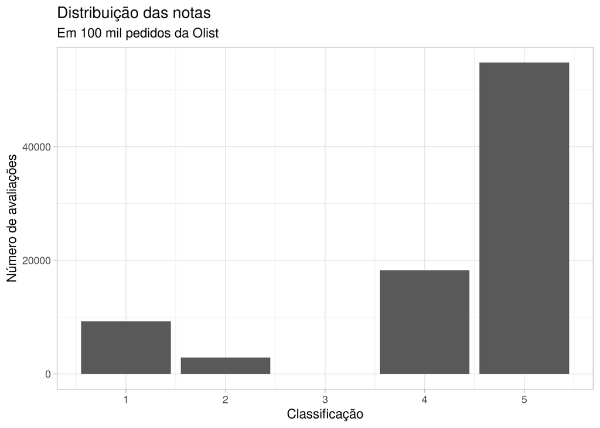

```r
avaliacoes %>%
  ggplot(aes(x = review_score)) +
  geom_bar() +
  labs(
    x = "Classificação",
    y = "Número de avaliações",
    title = "Distribuição das notas",
    subtitle = "Em 100 mil pedidos da Olist"
  )
```

```r
avaliacoes %>%
  count(review_score) %>%
  ungroup() %>%
  mutate(proportion = round(n/sum(n), 3)) %>%
  arrange(desc(review_score)) %>%
  gt()
```

| review_score | n | proportion |
| --- | --- | --- |
| 5 | 54826 | 0.643 |
| 4 | 18278 | 0.214 |
| 2 | 2903 | 0.034 |
| 1 | 9286 | 0.109 |

Criei a variável `review_sentiment` usando as regras acima. **Essa é a variável que vamos prever**. O objetivo principal é identificar que pedidos tendem a gerar avaliações negativas.

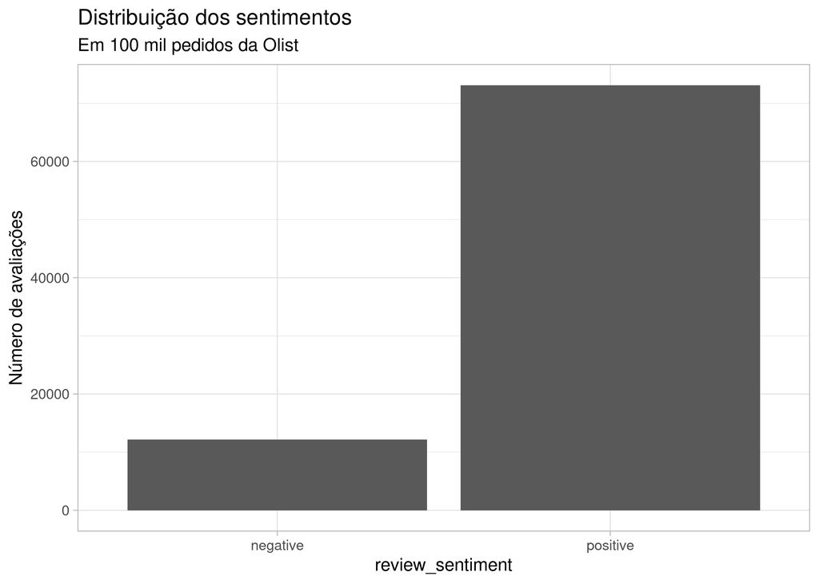

```r
avaliacoes %>%
  ggplot(aes(x = review_sentiment)) +
  geom_bar() +
  labs(
    x = "review_sentiment",
    y = "Número de avaliações",
    title = "Distribuição dos sentimentos",
    subtitle = "Em 100 mil pedidos da Olist"
  )
```

```r
avaliacoes %>%
  count(review_sentiment) %>%
  ungroup() %>%
  mutate(proportion = round(n/sum(n), 3)) %>%
  arrange(desc(n)) %>%
  gt()
```

| review_sentiment | n | proportion |
| --- | --- | --- |
| positive | 73104 | 0.857 |
| negative | 12189 | 0.143 |

## 3. Variáveis preditoras (features)

## 3.1 Correlações

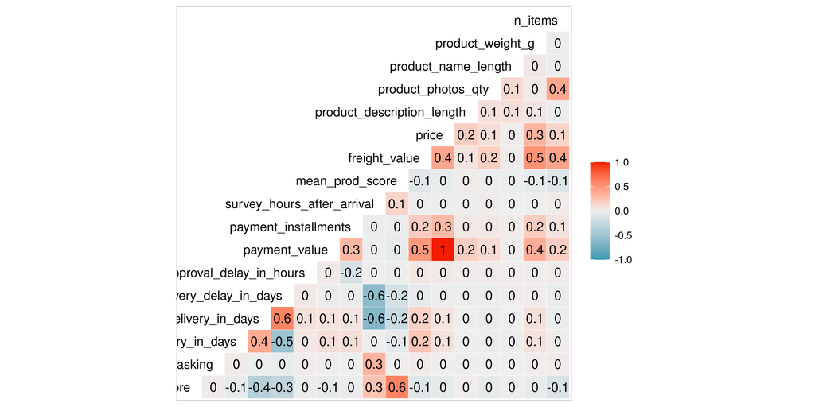

```r
avaliacoes %>%
  select_if(is.numeric) %>%
  na.omit() %>%
  ggcorr(label = T, hjust = 1)
```

A única correlação preocupante é entre `payment_value` (valor do pedido + frete) e `price` (soma dos valores dos produtos no pedido). Excluirei `price` da análise.

## 3.2 Distribuições

### a. Classificação média do produto: mean_prod_score

A nota média de cada produto nas avaliações. A ideia é que quanto menor a média, maior a tendência de que novas avaliações do mesmo produto tenham sentimento negativo, refletindo a qualidade do produto ou algum outro fator que cause insatisfação nos consumidores.

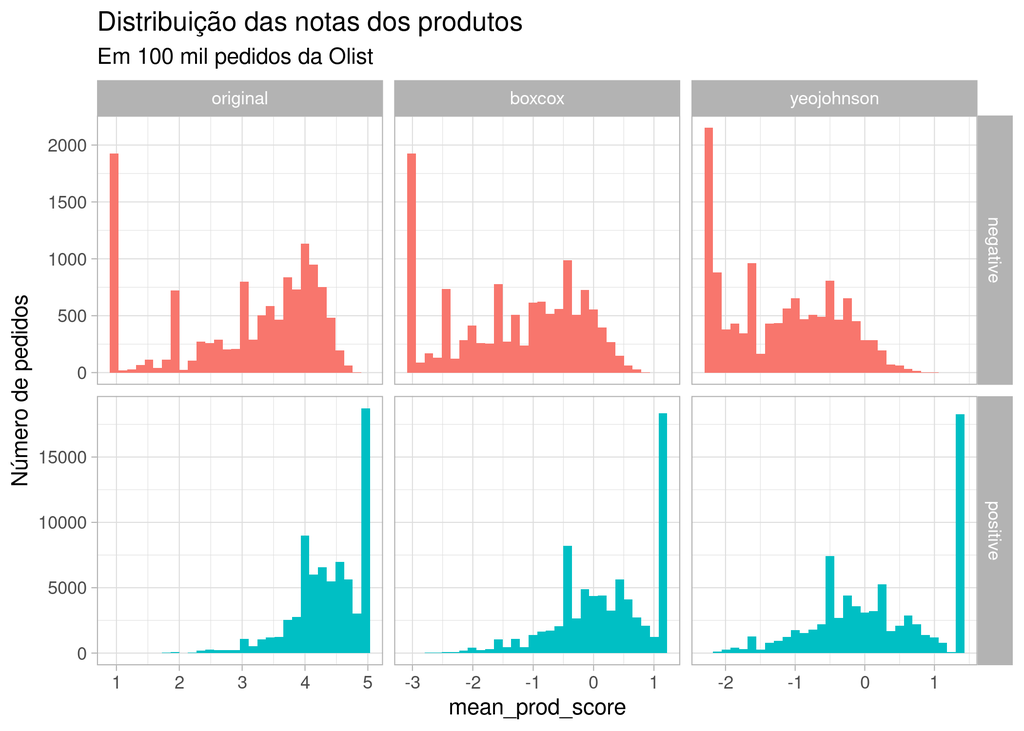

```r
avaliacoes %>%
  select(review_sentiment, mean_prod_score) %>%
  rename(original = mean_prod_score) %>%
  mutate(yeojohnson = predict(yeojohnson(original))) %>%
  mutate(boxcox = predict(boxcox(original))) %>%
  pivot_longer(c("original", "yeojohnson", "boxcox"),
               names_to = "transformation",
               values_to = "mean_prod_score") %>%
  mutate(transformation = factor(
    transformation,
    levels = c("original", "boxcox", "yeojohnson"),
    ordered = T
  )) %>%
  ggplot(aes(x = mean_prod_score, fill = review_sentiment)) +
  geom_histogram(show.legend = F) +
  labs(
    y = "Número de pedidos",
    title = "Distribuição das notas dos produtos",
    subtitle = "Em 100 mil pedidos da Olist"
  ) +
  facet_grid(review_sentiment ~ transformation, scales = "free")
```

As transformações de Box Cox e Yeo Johnson não mudam significativamente a distribuição original, que parece ser levemente deslocada nos produtos dos pedidos com avaliações positivas.

### b. Tempo entre email solicitando e postagem da avaliação: survey_hours_after_asking

O tempo entre solicitação da avaliação pela Olist e postagem da avaliação pelo usuário pode refletir o sentimento.

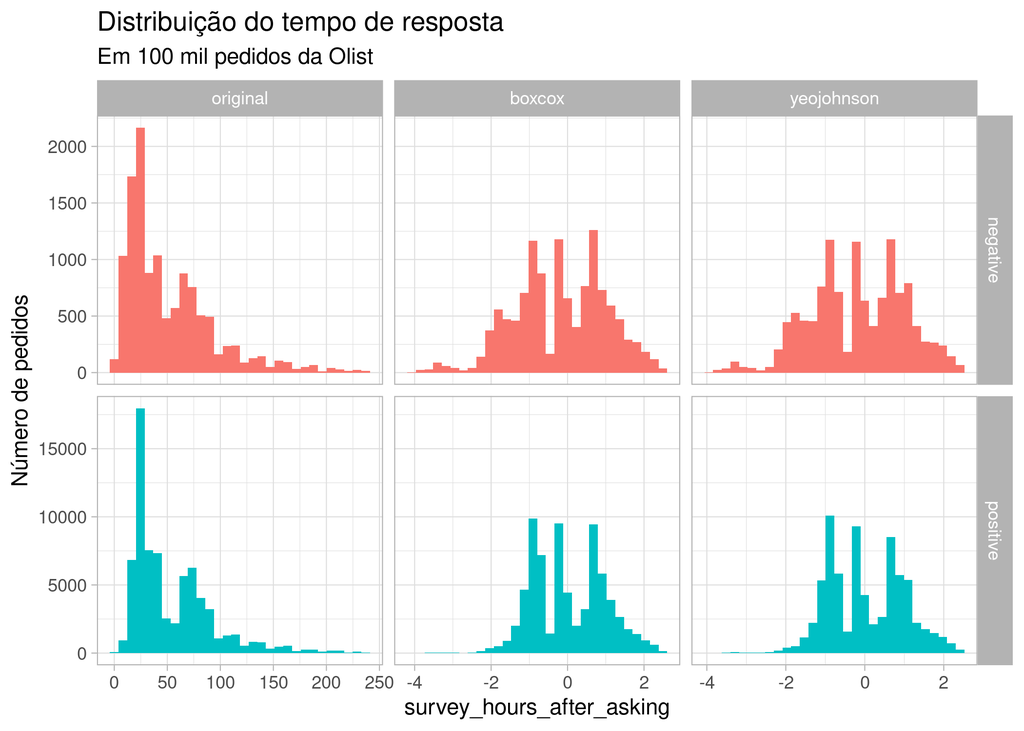

```r
avaliacoes %>%
  select(review_sentiment, survey_hours_after_asking) %>%
  rename(original = survey_hours_after_asking) %>%
  mutate(yeojohnson = predict(yeojohnson(original))) %>%
  mutate(boxcox = predict(boxcox(original))) %>%
  pivot_longer(c("original", "yeojohnson", "boxcox"),
               names_to = "transformation",
               values_to = "survey_hours_after_asking") %>%
  mutate(transformation = factor(
    transformation,
    levels = c("original", "boxcox", "yeojohnson"),
    ordered = T
  )) %>%
  ggplot(aes(x = survey_hours_after_asking, fill = review_sentiment)) +
  geom_histogram(show.legend = F) +
  labs(
    y = "Número de pedidos",
    title = "Distribuição do tempo de resposta",
    subtitle = "Em 100 mil pedidos da Olist"
  ) +
  facet_grid(review_sentiment ~ transformation, scales = "free")
```

Transformar os dados deixa as distribuições mais simétricas. Aqui parece não haver diferença no tempo entre as classes de sentimento.

### c. Valor do pagamento, método e parcelas: payment_value, payment_type e payment_installments

Quanto maior o valor do produto + frente, mais sensível o cliente a desvios de qualidade e atrasos.

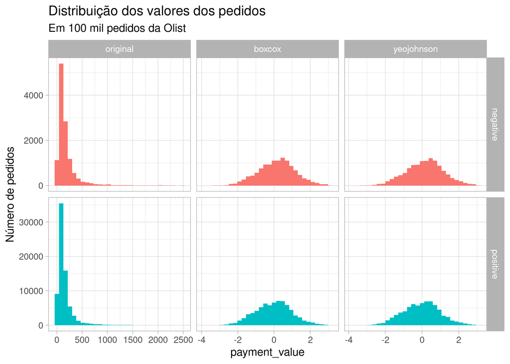

```r
avaliacoes %>%
  filter(payment_value <= 2500) %>% # Filtrando apenas para plotar
  select(review_sentiment, payment_value) %>%
  rename(original = payment_value) %>%
  mutate(yeojohnson = predict(yeojohnson(original))) %>%
  mutate(boxcox = predict(boxcox(original))) %>%
  pivot_longer(c("original", "yeojohnson", "boxcox"),
               names_to = "transformation",
               values_to = "payment_value") %>%
  mutate(transformation = factor(
    transformation,
    levels = c("original", "boxcox", "yeojohnson"),
    ordered = T
  )) %>%
  ggplot(aes(x = payment_value, fill = review_sentiment)) +
  geom_histogram(show.legend = F) +
  labs(
    y = "Número de pedidos",
    title = "Distribuição dos valores dos pedidos",
    subtitle = "Em 100 mil pedidos da Olist"
  ) +
  facet_grid(review_sentiment ~ transformation, scales = "free")
```

A distribuição dos valores é similar entre as classes de sentimento das avaliações. As transformações deixam as distribuições mais simétricas. Os valores originais são truncados e alguns outliers alongam a cauda.

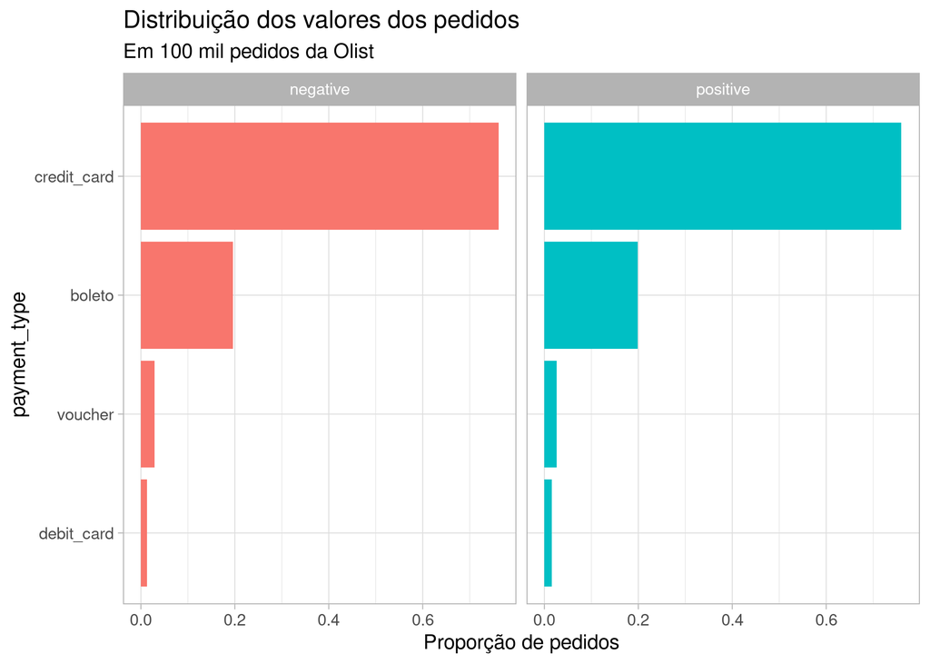

```r
avaliacoes %>%
  filter(!is.na(payment_type)) %>%
  group_by(review_sentiment, payment_type) %>%
  count(sort = T) %>%
  ungroup() %>%
  group_by(review_sentiment) %>%
  mutate(n = n/sum(n)) %>%
  mutate(payment_type = fct_reorder(payment_type, n)) %>%
  ungroup() %>%
  ggplot(aes(y = payment_type, x = n, fill = review_sentiment)) +
  geom_col(show.legend = F) +
  labs(
    x = "Proporção de pedidos",
    title = "Distribuição dos valores dos pedidos",
    subtitle = "Em 100 mil pedidos da Olist"
  ) +
  facet_wrap(~review_sentiment, ncol = 2)
```

Cartão de crédito é a forma de pagamento mais comum e as proporções são idênticas entre as duas classes de sentimento.

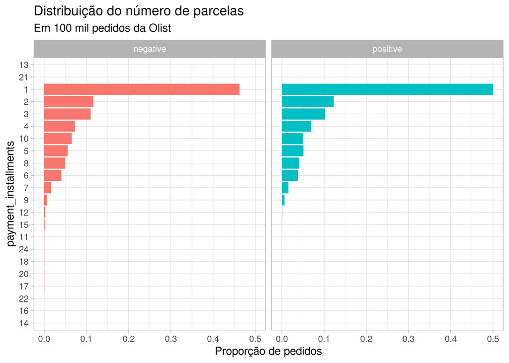

```r
avaliacoes %>%
  filter(!is.na(payment_installments), payment_installments > 0) %>%
  group_by(review_sentiment, payment_installments) %>%
  count(sort = T) %>%
  ungroup() %>%
  group_by(review_sentiment) %>%
  mutate(n = n/sum(n)) %>%
  mutate(payment_installments = fct_reorder(factor(payment_installments), n)) %>%
  ungroup() %>%
  ggplot(aes(y = payment_installments, x = n, fill = review_sentiment)) +
  geom_col(show.legend = F) +
  labs(
    x = "Proporção de pedidos",
    title = "Distribuição do número de parcelas",
    subtitle = "Em 100 mil pedidos da Olist"
  ) +
  facet_wrap(~review_sentiment, ncol = 2)
```

Os pedidos à vista são mais comuns. Não há diferenças entre as classes.

### d. estimated_delivery_in_days, delivery_in_days, delivery_delay_in_days, approval_delay_in_hours

As variáveis deste grupo se referem aos prazos do pedido. Quanto maior o prazo e o atraso, maior a tendência de instatisfação do consumidor.

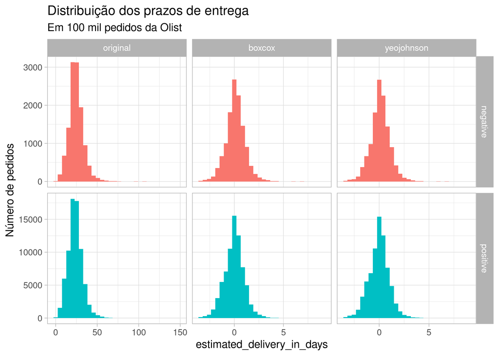

```r
avaliacoes %>%
  select(review_sentiment, estimated_delivery_in_days) %>%
  rename(original = estimated_delivery_in_days) %>%
  mutate(yeojohnson = predict(yeojohnson(original))) %>%
  mutate(boxcox = predict(boxcox(original))) %>%
  pivot_longer(c("original", "yeojohnson", "boxcox"),
               names_to = "transformation",
               values_to = "estimated_delivery_in_days") %>%
  mutate(transformation = factor(
    transformation,
    levels = c("original", "boxcox", "yeojohnson"),
    ordered = T
  )) %>%
  ggplot(aes(x = estimated_delivery_in_days, fill = review_sentiment)) +
  geom_histogram(show.legend = F) +
  labs(
    y = "Número de pedidos",
    title = "Distribuição dos prazos de entrega",
    subtitle = "Em 100 mil pedidos da Olist"
  ) +
  facet_grid(review_sentiment ~ transformation, scales = "free")
```

O prazo estimado de entrega tem um leve desvio de simetria que é corrigido pelas transformações. Não há diferença notável entre as classes.

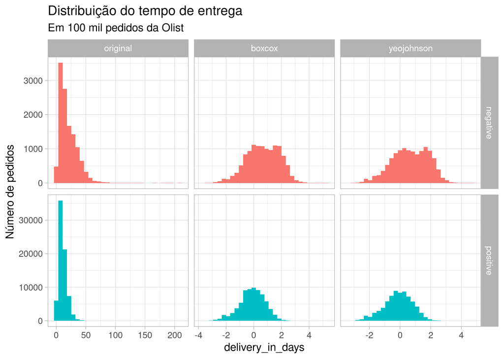

```r
avaliacoes %>%
  select(review_sentiment, delivery_in_days) %>%
  rename(original = delivery_in_days) %>%
  mutate(yeojohnson = predict(yeojohnson(original))) %>%
  mutate(boxcox = predict(boxcox(original))) %>%
  pivot_longer(c("original", "yeojohnson", "boxcox"),
               names_to = "transformation",
               values_to = "delivery_in_days") %>%
  mutate(transformation = factor(
    transformation,
    levels = c("original", "boxcox", "yeojohnson"),
    ordered = T
  )) %>%
  ggplot(aes(x = delivery_in_days, fill = review_sentiment)) +
  geom_histogram(show.legend = F) +
  labs(
    y = "Número de pedidos",
    title = "Distribuição do tempo de entrega",
    subtitle = "Em 100 mil pedidos da Olist"
  ) +
  facet_grid(review_sentiment ~ transformation, scales = "free")
```

O tempo que a encomenda levou para chegar ao destino é levemente maior para os pedidos com avaliações negativas. As transformações corrigem o desvio de simetria.

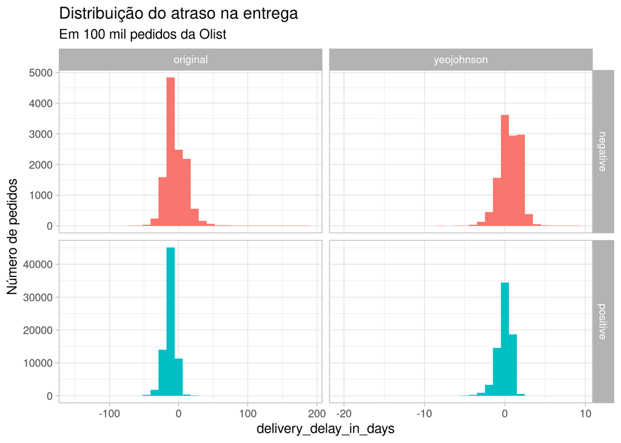

```r
avaliacoes %>%
  select(review_sentiment, delivery_delay_in_days) %>%
  rename(original = delivery_delay_in_days) %>%
  mutate(yeojohnson = predict(yeojohnson(original))) %>%
#  mutate(boxcox = predict(boxcox(original))) %>%
  pivot_longer(c("original", "yeojohnson"),
               names_to = "transformation",
               values_to = "delivery_delay_in_days") %>%
  mutate(transformation = factor(
    transformation,
    levels = c("original", "yeojohnson"),
    ordered = T
  )) %>%
  ggplot(aes(x = delivery_delay_in_days, fill = review_sentiment)) +
  geom_histogram(show.legend = F) +
  labs(
    y = "Número de pedidos",
    title = "Distribuição do atraso na entrega",
    subtitle = "Em 100 mil pedidos da Olist"
  ) +
  facet_grid(review_sentiment ~ transformation, scales = "free")
```

Os pedidos com sentimento negativo têm atrasos mais longos. Não apliquei a transformação de Box Cox por haver valores negativos.

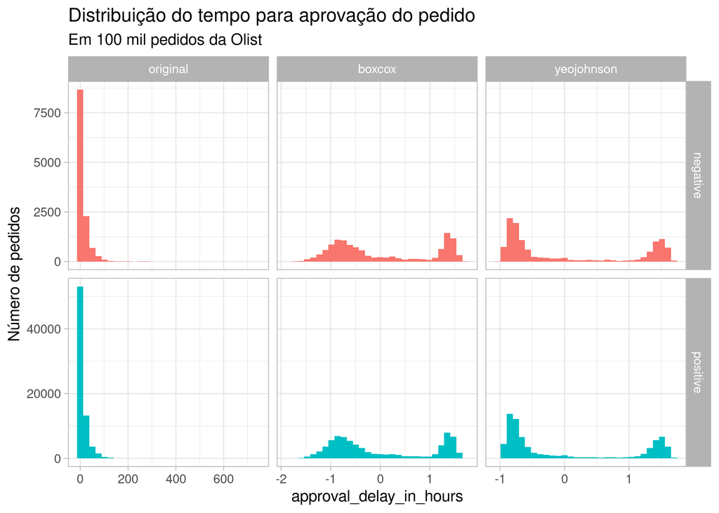

```r
avaliacoes %>%
  filter(!is.na(approval_delay_in_hours), approval_delay_in_hours > 0) %>%
  select(review_sentiment, approval_delay_in_hours) %>%
  rename(original = approval_delay_in_hours) %>%
  mutate(yeojohnson = predict(yeojohnson(original))) %>%
  mutate(boxcox = predict(boxcox(original))) %>%
  pivot_longer(c("original", "yeojohnson", "boxcox"),
               names_to = "transformation",
               values_to = "approval_delay_in_hours") %>%
  mutate(transformation = factor(
    transformation,
    levels = c("original", "boxcox", "yeojohnson"),
    ordered = T
  )) %>%
  ggplot(aes(x = approval_delay_in_hours, fill = review_sentiment)) +
  geom_histogram(show.legend = F) +
  labs(
    y = "Número de pedidos",
    title = "Distribuição do tempo para aprovação do pedido",
    subtitle = "Em 100 mil pedidos da Olist"
  ) +
  facet_grid(review_sentiment ~ transformation, scales = "free")
```

A distribuição do tempo necessário para aprovação do pedido é a mesma entre as classes.

### e. freight_value, product_description_length, product_photos_qty, n_items, product_category_name

As variáveis deste grupo indicam características dos produtos do pedido. Por exemplo, quanto menor a descrição do produto, maior a possibilidade de insatisfação por discrepâncias entre o entregue e o esperado.

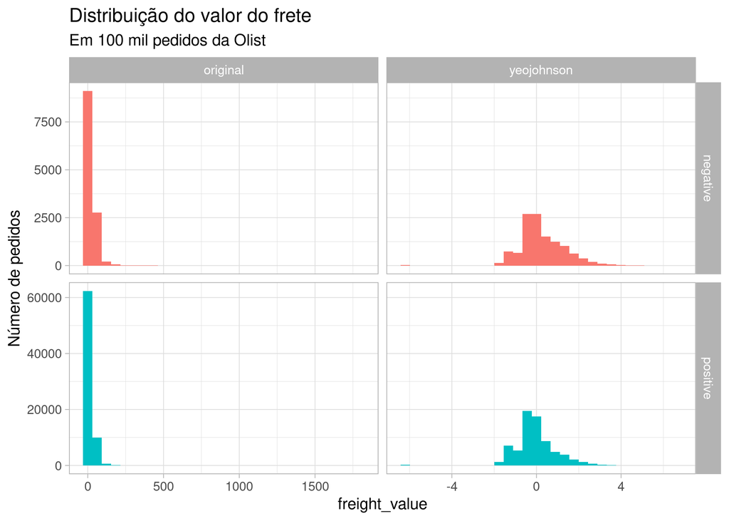

```r
avaliacoes %>%
  filter(!is.na(freight_value)) %>%
  select(review_sentiment, freight_value) %>%
  rename(original = freight_value) %>%
  mutate(yeojohnson = predict(yeojohnson(original))) %>%
  pivot_longer(c("original", "yeojohnson"),
               names_to = "transformation",
               values_to = "freight_value") %>%
  mutate(transformation = factor(
    transformation,
    levels = c("original", "yeojohnson"),
    ordered = T
  )) %>%
  ggplot(aes(x = freight_value, fill = review_sentiment)) +
  geom_histogram(show.legend = F) +
  labs(
    y = "Número de pedidos",
    title = "Distribuição do valor do frete",
    subtitle = "Em 100 mil pedidos da Olist"
  ) +
  facet_grid(review_sentiment ~ transformation, scales = "free")
```

Os valores do frete são ligeiramente maiores nos pedidos classificados como negativos.

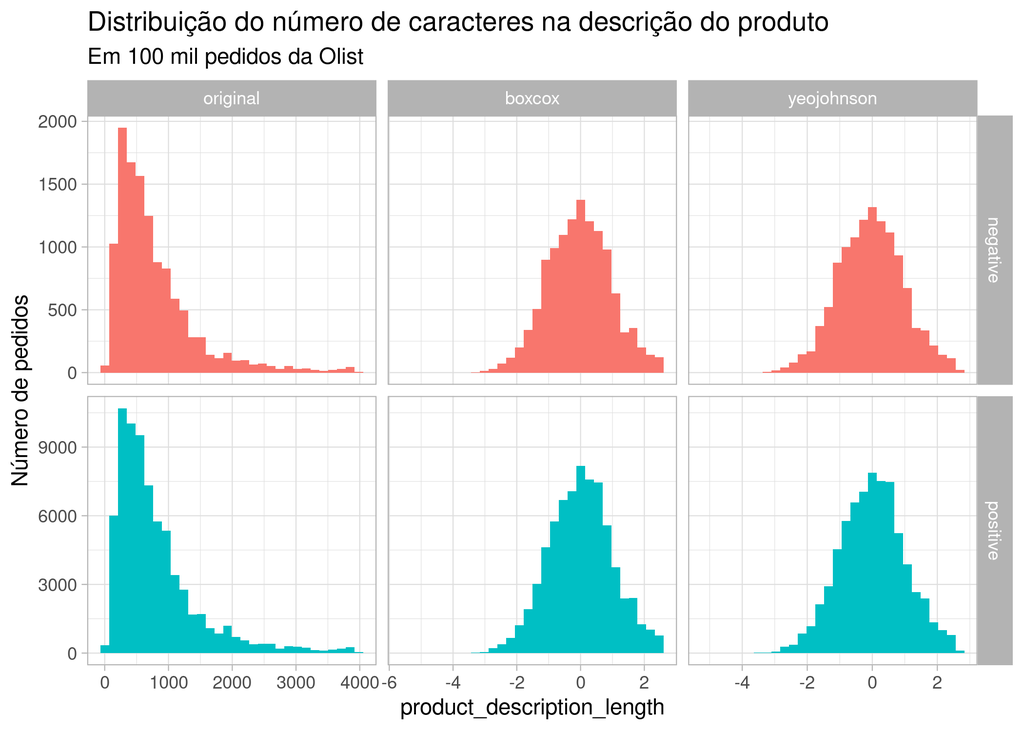

```r
avaliacoes %>%
  filter(!is.na(product_description_length)) %>%
  select(review_sentiment, product_description_length) %>%
  rename(original = product_description_length) %>%
  mutate(yeojohnson = predict(yeojohnson(original))) %>%
  mutate(boxcox = predict(boxcox(original))) %>%
  pivot_longer(c("original", "yeojohnson", "boxcox"),
               names_to = "transformation",
               values_to = "product_description_length") %>%
  mutate(transformation = factor(
    transformation,
    levels = c("original", "boxcox", "yeojohnson"),
    ordered = T
  )) %>%
  ggplot(aes(x = product_description_length, fill = review_sentiment)) +
  geom_histogram(show.legend = F) +
  labs(
    y = "Número de pedidos",
    title = "Distribuição do número de caracteres na descrição do produto",
    subtitle = "Em 100 mil pedidos da Olist"
  ) +
  facet_grid(review_sentiment ~ transformation, scales = "free")
```

A distribuição do número de caracteres é a mesma entre as classes.

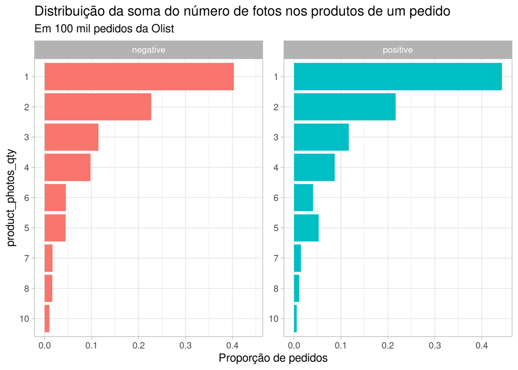

```r
avaliacoes %>%
  filter(!is.na(product_photos_qty)) %>%
  group_by(review_sentiment, product_photos_qty) %>%
  count(sort = T) %>%
  ungroup() %>%
  group_by(review_sentiment) %>%
  mutate(n = n/sum(n)) %>%
  arrange(desc(n)) %>%
  top_n(9) %>%
  mutate(product_photos_qty = fct_reorder(factor(product_photos_qty), n)) %>%
  ungroup() %>%
  ggplot(aes(y = product_photos_qty, x = n, fill = review_sentiment)) +
  geom_col(show.legend = F) +
  labs(
    x = "Proporção de pedidos",
    title = "Distribuição da soma do número de fotos nos produtos de um pedido",
    subtitle = "Em 100 mil pedidos da Olist"
  ) +
  facet_wrap(~review_sentiment, ncol = 2, scales = "free_y")
```

## 4. Análises

### 4.1 Modelo logístico com regularização

Dividi o conjunto de dados em dois subconjuntos: treino, com 80% dos dados e teste, com os 20% restantes. Como as classes de sentimento são desbalanceadas, fiz uma amostragem estratificada.

```r
set.seed(2021)
avaliacoes_split <- initial_split(avaliacoes, prop = 0.8, strata = review_sentiment)
avaliacoes_treino <- training(avaliacoes_split)
avaliacoes_test <- testing(avaliacoes_split)
```

Em seguida, criei um grupo de conjuntos de validação cruzada com 10 folds para comparar os modelos e ajustar os hiperparâmetros. A amostragem também foi estratificada.

```r
set.seed(2021)
avaliacoes_validacao <- vfold_cv(avaliacoes_treino, v = 10, strata = review_sentiment)
```

Seguindo o workflow do tidymodels, criei uma receita para indicar a fórmula do modelo e os ajustes necessários aos dados. Criei um nível “unknown” para os fatores com níveis omitidos, criei variáveis dummy para todas as variáveis categóricas, imputei a mediana às variáveis numéricas, transformei seguindo Yeo Johnson, criei termos de interações entre as variáveis provavelmente mais importantes, padronizei e centralizei os valores.

```r
receita_dados <- recipe(review_sentiment ~ survey_hours_after_asking + estimated_delivery_in_days + delivery_in_days + delivery_delay_in_days + approval_delay_in_hours + payment_value + payment_installments + payment_type + survey_hours_after_arrival + mean_prod_score + freight_value + product_description_length + product_photos_qty + n_items, data = avaliacoes_treino) %>%
  step_unknown(all_nominal_predictors()) %>%
  step_dummy(all_nominal(), -all_outcomes()) %>%
  step_impute_median(all_numeric_predictors()) %>%
  step_YeoJohnson(all_numeric_predictors()) %>%
  step_interact(term = ~ payment_value:mean_prod_score + mean_prod_score:delivery_delay_in_days) %>%
  step_zv(all_predictors()) %>%
  step_normalize(all_predictors())
```

O primeiro modelo é uma regressão logística com penalizacão. O tipo (Lasso ou Ridge) e o lâmbda serão ajustados via grid search.

```r
log_mod <- logistic_reg(penalty = tune(), mixture = tune()) %>%
  set_engine("glmnet", family = "binomial")
```

Criando um workflow com a receita e o modelo.

```r
log_wf <- workflow() %>%
  add_recipe(receita_dados) %>%
  add_model(log_mod)
```

Ajustando o lâmbda e o tipo de penalização com grid search e cross-validation. O grid aqui é uma combinação simples entre lâmbda (30) e tipo de penalização (2). Assim, são 60 modelos para cada fold.

```r
log_mod_res <-
  log_wf %>%
  tune_grid(
    avaliacoes_validacao,
    grid = crossing(
      penalty = 10 ^ seq(-4,-1, length.out = 30),
      mixture = 0:1
    ),
    control = control_grid(
      save_pred = T,
      save_workflow = F,
      extract = extract_model
    ),
    metrics = metric_set(accuracy)
  )
```

Plotando o resultado do grid search.

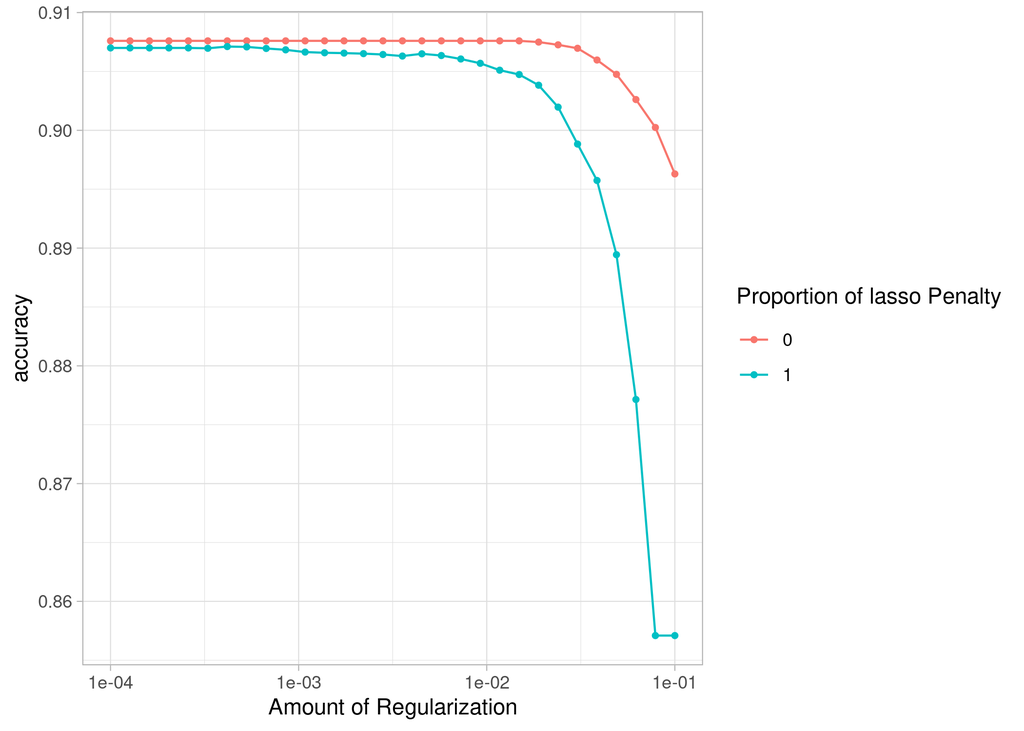

```r
autoplot(log_mod_res)
```

```r
log_mod_best <- log_wf %>%
  finalize_workflow(select_best(log_mod_res))
```

Fazendo o último ajuste no melhor modelo: ajustando o modelo com todos os dados de treino e calculando as métricas (acurácia e ROC) no conjunto de testes.

```r
log_mod_best_fit <- log_mod_best %>%
  last_fit(avaliacoes_split)
```

Plotando as variáveis mais importantes:

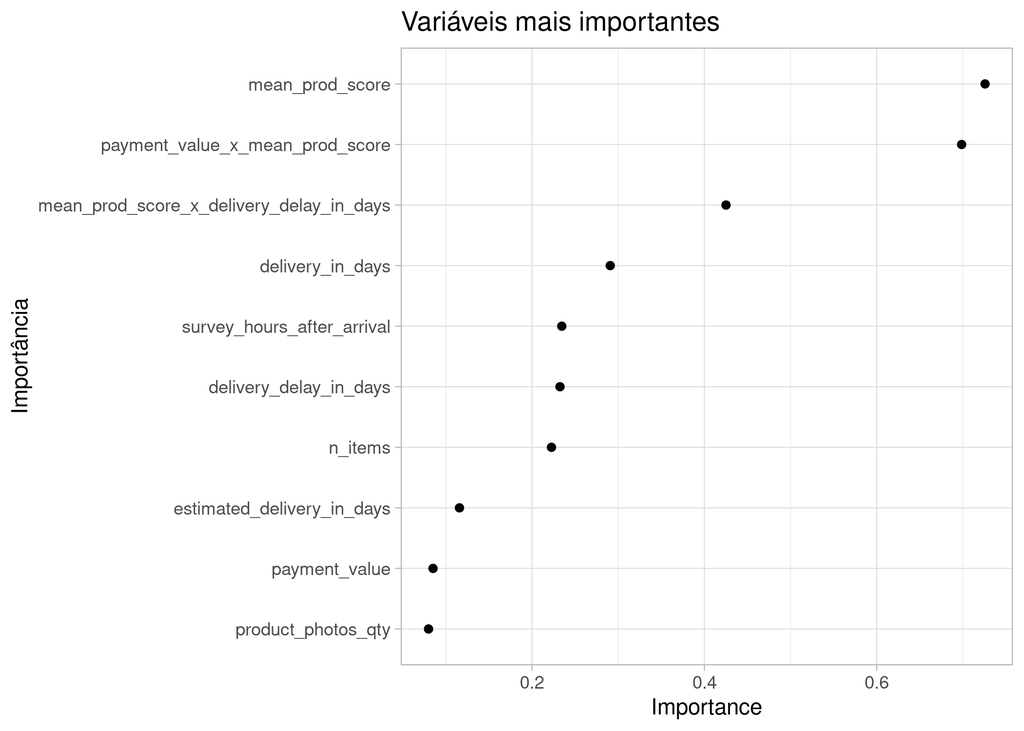

```r
log_mod_best %>%
  fit(avaliacoes_treino) %>%
  pull_workflow_fit() %>%
  vip(geom = "point") +
  labs(title = "Variáveis mais importantes", x = "Importância")
```

As métricas de ajuste do modelo:

```r
log_mod_best_fit %>%
  collect_metrics() %>%
  gt()
```

| .metric | .estimator | .estimate | .config |
| --- | --- | --- | --- |
| accuracy | binary | 0.9082009 | Preprocessor1_Model1 |
| roc_auc | binary | 0.9043568 | Preprocessor1_Model1 |

A acurácia foi de 90% e a área sob a curva ROC também 90%.

```r
log_conf_mat <- log_mod_best_fit %>%
  collect_predictions() %>%
  conf_mat(review_sentiment, .pred_class)

log_conf_mat
```

```
##           Truth
## Prediction negative positive
##   negative     1146      274
##   positive     1292    14347
```

Apesar da acurácia de 90%, a matriz de confiança indica que esse valor elevado se deu principalmente devido à diferença no número de pedidos entre as classes. Para o negócio, o valor está em identificar corretamente os pedidos com sentimento negativo. No conjunto de testes, havia 2438 pedidos avaliados negativamente. Desses, o modelo foi capaz de prever corretamente 1146 (47.01%) das avaliações negativas. As avaliações positivas foram identificadas corretamente em 98% dos casos.

Variáveis como a histórico de avaliações do consumidor e um conjunto maior de dados provavelmente melhorariam o modelo. Do ponto de vista do negócio, se o custo de falso negativos não for um impeditivo, é possível aumentar a sensibilidade ajustando a probabilidade mínima para que uma avaliação seja prevista como negativa:

```r
log_conf_mat_new <- log_mod_best_fit %>%
  collect_predictions() %>%
  mutate(new_pred = factor(if_else(.pred_negative > 0.2, "negative", "positive"))) %>%
  conf_mat(review_sentiment, new_pred)

log_conf_mat_new
```

```
##           Truth
## Prediction negative positive
##   negative     1850     1894
##   positive      588    12727
```

Diminuindo a probabilidade para 0.2, o modelo passa a identificar corretamente 75.88% das avaliações negativas. Em contrapartida, as avaliações positivas seriam identificadas corretamente em 87% dos casos. O custo dos novos falso negativos é impeditivo, mesmo com o aumento dos negativos verdadeiros? Desconsiderando o fator financeiro, provavelmente não. Por exemplo, se o objetivo for fazer uma campanha via emails para melhorar a satisfação dos clientes, não há problema em tratar os clientes satisfeitos como insatisfeitos. Porém, se a campanha envolver telefonemas ou outro acompanhamento mais caro, pode ser que o custo dos falsos negativos se torne um problema.

### 4.2 XGBoost

Para tentar melhorar as previsões de negativos verdadeiros sem aumentar os falsos negativos, construí um modelo XGBoost para classificação usando a mesma receita do modelo logístico acima: divisão 80/20 treino e testes, 10-fold cross-validation para ajustar os hiperparâmetros e um grid search com tamanho 10 e seguindo o esquema latin hypercube, já que o modelo XGBoost leva um tempo consideravalmente maior para rodar.

```r
doParallel::registerDoParallel(cores = 12)
xgb_mod <- boost_tree(
  mtry = tune(),
  trees = tune(),
  tree_depth = tune(),
  learn_rate = tune(),
  min_n = tune(),
  loss_reduction = tune(),
  sample_size = tune()
) %>%
  set_engine("xgboost") %>%
  set_mode("classification")

xgb_wf <- workflow() %>%
  add_recipe(receita_dados) %>%
  add_model(xgb_mod)

xgb_grid <- grid_latin_hypercube(
  tree_depth(),
  min_n(),
  loss_reduction(),
  learn_rate(range = c(0.01, 0.3), trans = NULL),
  trees(range = c(200, 800)),
  sample_size = sample_prop(),
  finalize(mtry(), avaliacoes_treino),
  size = 10
)

xgb_res <- tune_grid(
  xgb_wf,
  resamples = avaliacoes_validacao,
  grid = xgb_grid,
  metrics = metric_set(accuracy),
  control = control_grid(
    save_pred = T,
    save_workflow = F
  )
)
```

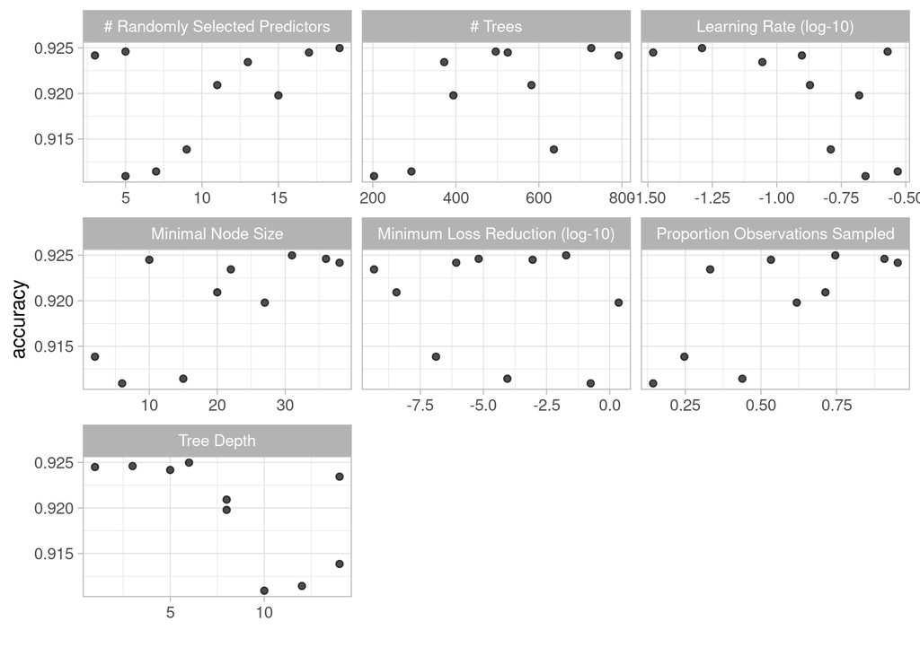

```r
autoplot(xgb_res)
```

Os hiperparâmetros pouco influenciaram na acurácia do modelo XGBoost. O próximo passo é finalizar o workflow e ajustar o modelo com todo o conjunto de treino e fazer as previsões com o de testes.

```r
xgb_mod_best <- xgb_wf %>%
  finalize_workflow(select_best(xgb_res))

xgb_mod_best_fit <- xgb_mod_best %>%
  last_fit(avaliacoes_split)
```

```r
xgb_mod_best %>%
  fit(avaliacoes_treino) %>%
  pull_workflow_fit() %>%
  vip(geom = "point") +
  labs(title = "Variáveis mais importantes", x = "Importância")
```

```
## [16:53:07] WARNING: amalgamation/../src/learner.cc:1095: Starting in XGBoost 1.3.0, the default evaluation metric used with the objective 'binary:logistic' was changed from 'error' to 'logloss'. Explicitly set eval_metric if you'd like to restore the old behavior.
```

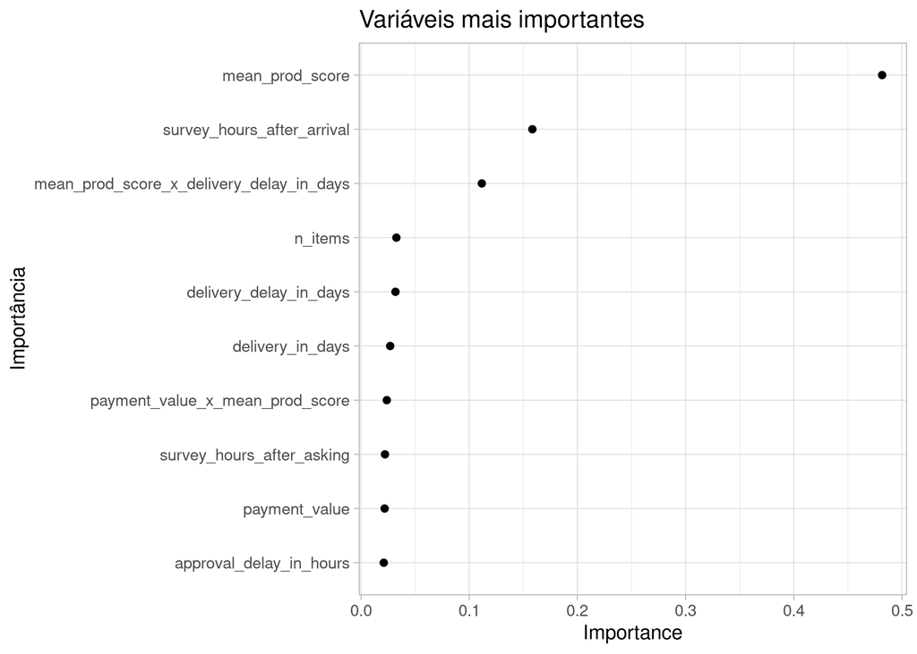

```r
preds <- xgb_mod_best_fit %>% collect_predictions()
```

```r
xgb_mod_best_fit %>%
  collect_metrics() %>%
  gt()
```

| .metric | .estimator | .estimate | .config |
| --- | --- | --- | --- |
| accuracy | binary | 0.9256697 | Preprocessor1_Model1 |
| roc_auc | binary | 0.9193502 | Preprocessor1_Model1 |

A acurácia do modelo é de 92%.

```r
xgb_conf_mat <- preds %>%
  conf_mat(review_sentiment, .pred_class)

xgb_conf_mat
```

```
##           Truth
## Prediction negative positive
##   negative     1356      186
##   positive     1082    14435
```

A matriz de confusão indica que o modelo XGBoost detecta os negativos de maneira ligeiramente mais eficiente: 55.62% das avaliações negativas identificadas corretamente. As avaliações positivas foram identificadas corretamente em 98.73% dos casos.

```r
xgb_conf_mat_new <- preds %>%
  mutate(new_pred = factor(if_else(.pred_negative > 0.2, "negative", "positive"))) %>%
  conf_mat(review_sentiment, new_pred)

xgb_conf_mat_new
```

```
##           Truth
## Prediction negative positive
##   negative     1757     1242
##   positive      681    13379
```

A matriz de confusão com o limite modificado para 0.2 mostra que o modelo XGBoost consegue identificar 72.07% das avaliações negativas. Mais uma vez, é preciso entender o que se pretende com o modelo no nível do negócio para identificar o ponto de corte com melhor custo-benefício.

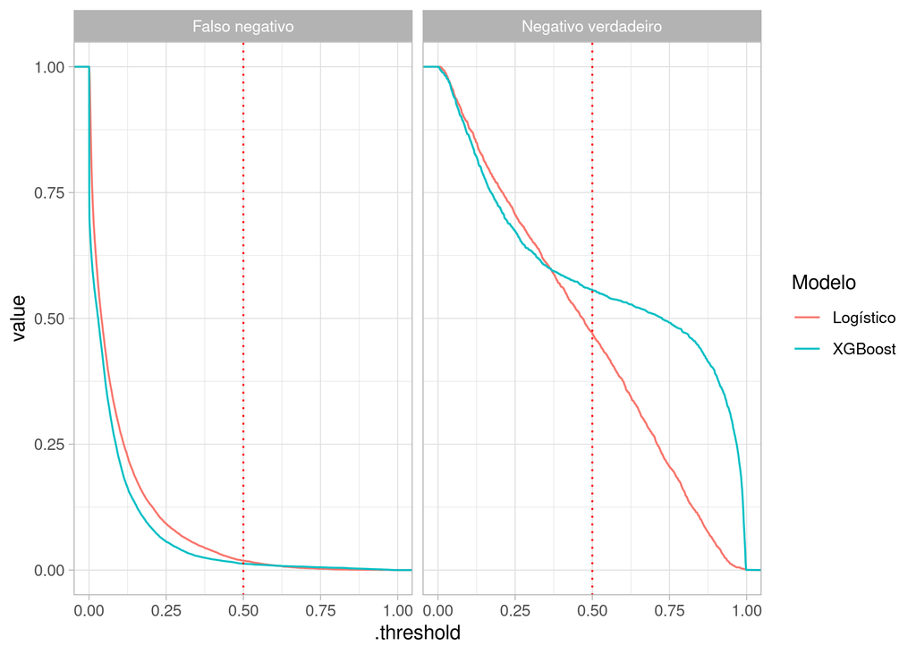

```r
bind_rows(
preds %>%
  roc_curve(review_sentiment, .pred_negative) %>%
  mutate(Modelo = "XGBoost"),
log_mod_best_fit %>%
  collect_predictions() %>%
  roc_curve(review_sentiment, .pred_negative) %>%
  mutate(Modelo = "Logístico")
) %>%
  mutate(specificity = 1 - specificity) %>%
  rename(`Negativo verdadeiro` = sensitivity, `Falso negativo` = specificity) %>%
  pivot_longer(c("Falso negativo", "Negativo verdadeiro"), names_to = "metric", values_to = "value") %>%
  mutate(metric = factor(metric), Modelo = factor(Modelo)) %>%
  ggplot(aes(x = .threshold, y = value, col = Modelo)) +
  geom_path() +
  geom_vline(xintercept = 0.5, col = "red", linetype = "dotted") +
  facet_wrap(~metric)
```

Abaixo o código de um ensemble entre os dois modelos, mas as previsões não melhoram. Deixei apenas como referência. Caso queira testar, a métrica nos grid search tem que ser alterada para roc_auc.

```r
log_best <- log_mod_res %>% filter_parameters(parameters = select_best(log_mod_res))
xgb_best <- xgb_res %>% filter_parameters(parameters = select_best(xgb_res))

log_xgb_blend <- stacks() %>%
  add_candidates(log_best) %>%
  add_candidates(xgb_best) %>%
  blend_predictions()

log_xgb_fit <- log_xgb_blend %>%
  fit_members()

blend_pred <- log_xgb_fit %>%
  predict(avaliacoes_test, type = "class", members = TRUE)
```

```r
log_xgb_fit %>%
  predict(avaliacoes_test, type = "class", members = TRUE) %>%
  bind_cols(avaliacoes_test) %>%
  conf_mat(review_sentiment, .pred_class_xgb_best_1_09)
```

[output not shown]